# Course Introduction

MATH-7360 Data Analysis

Dr. Xiang Ji @ Tulane University

Aug 22, 2021

## Annoucement

1. Respond to the introduction discussion [self-introduction](https://tulane.instructure.com/courses/2238421/discussion_topics/13241432?module_item_id=30871904).
2. We will do self-introduction this Friday via zoom.

## Course logistics

- Course GitHub organization invitation https://github.com/tulane-math-7360-2021
  - Go to [GitHub Education](https://education.github.com/) to get your student benifit (you need to **use your tulane.edu** email address).
  - Once you have got your GitHub id, please tell me through email (xji4@tulane.edu). Your GitHub id will then be invited to the [course GitHub organization](https://github.com/tulane-math-7360-2021).
  - Project and homework submission via GitHub
  - Our course has a GitHub page. Please take a look at https://tulane-math-7360-2021.github.io/ and its source code at https://github.com/tulane-math-7360-2021/tulane-math-7360-2021.github.io. You could check all the development history of this website through the [commit history](https://github.com/tulane-math-7360-2021/tulane-math-7360-2021.github.io/commits/main).
- Lab sessions
  - There will be recordings (not many) in the future.
  - *Do* need to submit the lab “work” by pushing it to your Git Repo on the course organization.
  - There will be “solutions” posted (after the following Monday lecture) for future lab sessions (when there are questions).
- Using R is a course objective
  - try to use R as much as possible for lab sessions and homework assignments
  - free to use any language for course project
- Homework assignment starts week 2. 1st assignment due on week 4. Expected frequency: one per 2-3 weeks.
- Will provide optional reading material on Course Webpage.
- Github page contains the most up-to-date materials.

## Course Project

- Find a dataset of interest to you.
- Turn in a brief one-page description by the end of week 3. (points: 3/30)
- Submit a mid-term report (2 - 4 pages, no more than 4 please) by the end of week 12. (points: 7/30)
- Present your work to your peers week 15 and 16 (December 3, 6, 8, and 10). (points: 10/30)
- Submit a final report (4 - 8 pages, no more than 8 please) by the end of the semester by December 18 (early submissions are encouraged).
- Submit code to your own private GitHub repository on the course GitHub organization by December 18. (Report + Code, points: 10/30)
- (Optional) make a GitHub page for your project.
- (Optional) make an R shiny app to showcase your findings.

### Project ideas/Dataset resources

- Amazon data http://jmcauley.ucsd.edu/data/amazon/, https://nijianmo.github.io/amazon/index.html, https://cseweb.ucsd.edu/~jmcauley/datasets.html
- [Netflix challenge](https://www.netflixprize.com/rules.html)
- Sports/eSports prediction
- Hurricane prediction!
- 1000 human genome project
- Reproduce findings of a paper in your field (could be hard).
- Google “data science projects” to get more ideas

### More potential data source

([reference](https://sta199-f21-001.netlify.app/project/))

- [R Data Sources for Regression Analysis](https://rfun.library.duke.edu/blog/data-sources-for-regression-analysis/)
- [kaggle](https://www.kaggle.com/datasets)
- [FiveThirtyEight data](https://data.fivethirtyeight.com/)
- [TidyTuesday](https://github.com/rfordatascience/tidytuesday)

Additions:

- [World Health Organization](https://www.who.int/gho/database/en/)
- [The National Bureau of Economic Research](https://data.nber.org/data/)
- [International Monetary Fund](https://data.imf.org/?sk=388DFA60-1D26-4ADE-B505-A05A558D9A42&sId=1479329328660)
- [General Social Survey](http://gss.norc.org/)
- [United Nations Data](http://data.un.org/)
- [United Nations Statistics Division](https://unstats.un.org/home/)
- [U.K. Data](https://data.gov.uk/)
- [U.S. Data](https://www.data.gov/)
- [U.S. Census Data](https://www.census.gov/data.html)
- [European Statistics](https://ec.europa.eu/eurostat/)
- [Statistics Canada](https://www.statcan.gc.ca/eng/start)
- [Pew Research](https://www.pewresearch.org/download-datasets/)
- [UNICEF](https://data.unicef.org/)
- [CDC](https://www.cdc.gov/datastatistics/index.html)
- [World Bank](https://datacatalog.worldbank.org/)
- [Election Studies](https://electionstudies.org//)

### Brief Description components

- Introduce the dataset (data type, origin, etc). Explain why you choose the dataset. List some questions you want to explore with the dataset.

### Mid-term report components

- Include the brief description with modifications if needed
- Give an abstract on your plan
  - What analyses you want to perform for answering your questions
- Current progress and future plan

### Final report components

- Introduce the dataset. Explain why you choose it. Explain what questions you want to ask and explore using the dataset.
- Analysis. Explain the statistical methods that you use for analyzing the dataset. Explain what you have done to generate the results (make your analysis reproducible).
- Results. Illustrate your results. Use figures and tables to imiprove readability.
- Discussions. This is the place to put in almost whatever you want to share. Some difficulties you met in the analysis, what you learned from the analysis, some future directions.

## Comments from 2020 course evaluations

From “Additional comments about your experience in this course”:

- I learned more from going through the material in the labs than in the actual lectures. I think that maybe smaller homework assignments more frequently would have been more effective than three huge assignments.
- I thought the course was well organized. The notes were easy to access for later reference which was really helpful. I think the only thing that could be improved upon is spending a little less time on learning R and spending more time discussing the theory behind Data Analysis. Some of the concepts addressed at the end felt rushed and they were the concepts with which I wanted to spend more time.
- Awesome! Professor Ji is very nice. He answered all my confusions. He always explain things clear enough for us to comprehend.
- Dr. Ji is very knowledgeable and goes out of his way to be available as a resource for students needing help with the course or outside R/research/data questions. He made the structure of the course very flexible without sacrificing rigor, which I think everyone really appreciated during this stressful semester. I had experience in statistics/R going in, but have improved so much and learned so many new packages and strategies thanks to this course. I especially benefitted from the homework assignments, which provided practice with skills that I have been able to immediately apply to my research.

From “Comment on the strongest aspects of this course”:

- I liked that this class had a lab component. The labs were helpful in making sure that I was understanding the material.
- I received a lot of help from Professor Xiang, who was always was ready to answer my questions in class or through email.
  - Well, Xiang is my first name…
- Dr. Ji was by far the best part of the course. He was extremely helpful and prompt with responses to questions. He wanted us to do well in the course.
- Useful in learning R
- This course started from the very basics and covered a lot of information quickly, but was extremely useful and approachable for students coming from different departments with different levels of previous experience. I really appreciated that the course was tailored towards providing a brief overview of many relevant topics and developing practical skills, rather than memorizing formulas or taking long comprehensive exams. I would highly recommend taking this course with Dr. Ji to anyone who uses R or wants to start learning.

## Giant’s shoulders

- Previous lecture notes from Dr. Michelle Lacey (Math Department @ Tulane)
- Course material from Dr. Hua Zhou (Biostatistics Department @ UCLA)
- Various online sources

## Statistics and data science

- Statistics, the science of *data analysis*, is the applied mathematics in the 21st century.
- Data is increasing in [volume, velocity, and variety](http://www.forbes.com/sites/oreillymedia/2012/01/19/volume-velocity-variety-what-you-need-to-know-about-big-data/).
- My favorite definition of a *data scientist*:

> A data scientist is someone who is better at statistics than any software engineer and better at software engineering than any statistician.

## Big data in 1990s

@Huber94HugeData; @Huber96MassiveData

| Data Size | Bytes | Storage Mode |
| --- | --- | --- |
| tiny | $10^2$ | piece of paper |
| small | $10^4$ | a few pieces of paper |
| medium | $10^6$ (MB) | a floppy disk |
| large | $10^8$ | hard disk |
| huge | $10^9$ (GB) | hard disk(s) |
| massive | $10^{12}$ (TB) | hard disk(s); RAID storage |

## Big data in 21st centry

Four V’s of big data:

[figure not shown]

Source: [IBM](http://www.ibmbigdatahub.com/infographic/four-vs-big-data).

## A typical data scientist on [Linkedin](http://linkedin.com)

[figure not shown]

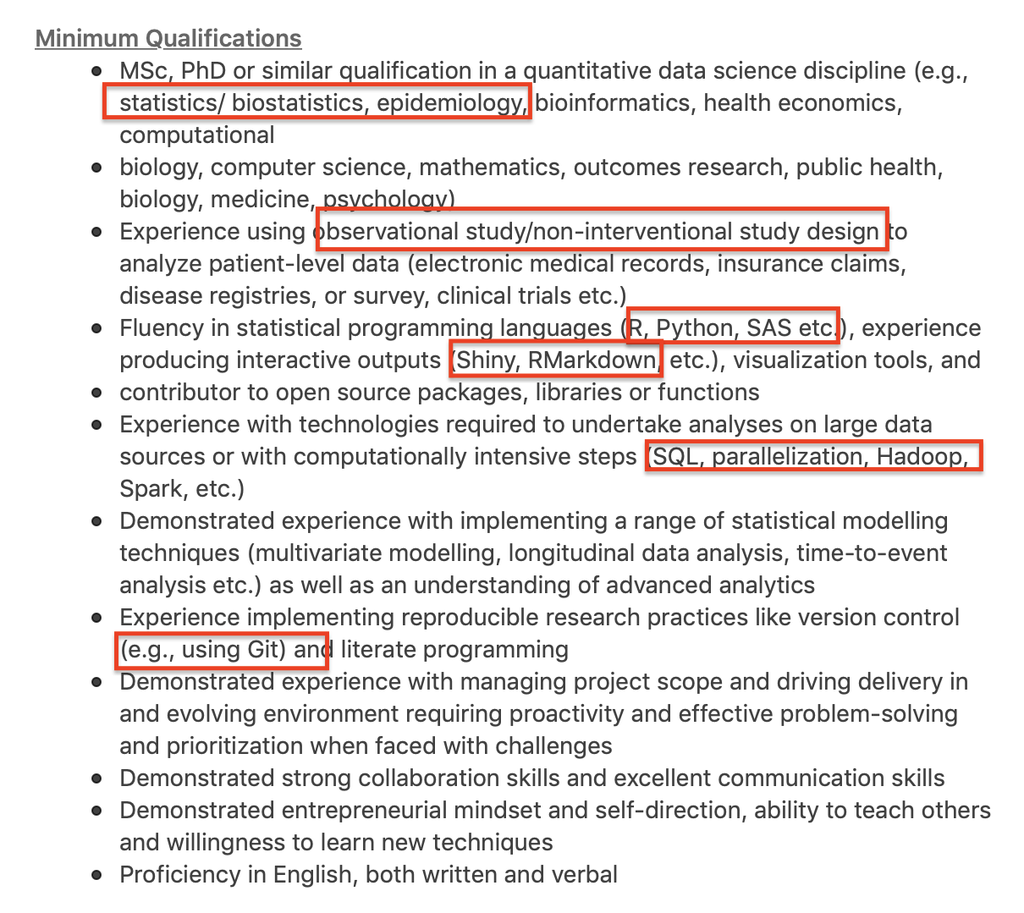

## A random [online cartoon](https://cheezburger.com/6619141/19-nerdy-tech-memes-thatll-debug-your-brain) for data scientist

[figure not shown]

## Course description

- This course introduces some computing skills and software tools for handling data.
- Read syllabus and [About the course](https://tulane.instructure.com/courses/2238421/pages/about-the-course) for a tentative list of topics and course logistics.